[figure not shown]

# Migrating historical AEA supplements - DRAFT

*Author: Lars Vilhuber, Cornell University, AEA Data Editor (dataeditor@aeapubs.org)*

*Last updated: 2020-05-15*

Since July 16, 2019, the American Economic Association has used the **[AEA Data and Code Repository](https://www.openicpsr.org/openicpsr/aea)** at **[openICPSR](https://www.openicpsr.org/openicpsr/)** as the default archive for its supplements. This archive serves a dual purpose: to share data with the AEA Data Editor prior to being published, and as a publication outlet for supplements to articles in AEA journals.

At the time, the AEA also announced that it would migrate the historical supplements, hitherto stored as ZIP files on the [AEA website](https://www.aeaweb.org/journals), into the AEA Data and Code Repository.

On Oct 1, 2019, openICPSR had 867 deposits, which covered 94 deposits in the [DataLumos](https://www.datalumos.org/datalumos/search/studies) archive, 46 in the [AERA archive](https://www.openicpsr.org/openicpsr/search/aerajournals/studies), and 13 in the [PSID](https://www.openicpsr.org/openicpsr/search/psid/studies) archive. The **AEA Data and Code Repository** contained at the time 93 deposits, of which 5 were public, the others awaiting publication of the associated article.

## Increased findability

The migrated archives are now available through the [openICPSR search interface](https://www.openicpsr.org/openicpsr/search/aea/studies), the [general ICPSR search interface](https://www.icpsr.umich.edu/icpsrweb/ICPSR/search/studies), as well as through a variety of federated search interfaces such as [Google Dataset Search](https://toolbox.google.com/datasetsearch/search). For instance, the current AER Editor’s supplements can be found [here](https://www.openicpsr.org/openicpsr/search/aea/studies?start=0&ARCHIVE=aea&sort=score%20desc%2CTITLE_SORT%20asc&rows=25&q=esther%20duflo), [here](https://www.icpsr.umich.edu/icpsrweb/ICPSR/search/studies?start=0&ARCHIVE=ICPSR&PUBLISH_STATUS=PUBLISHED&sort=score%20desc%2CTITLE_SORT%20asc&rows=50&q=esther%20duflo) and [here](https://toolbox.google.com/datasetsearch/search?query=esther%20duflo), with increasing generality.

## Characteristics of AEA supplement data

We can describe this subset of the historical supplements in a variety of ways.

### Time coverage

This is only a subset of all supplements, so what years are covered?

| year | count |
| --- | --- |
| 1999 | 2 |
| 2000 | 2 |
| 2004 | 24 |
| 2005 | 280 |
| 2006 | 7 |
| 2007 | 625 |
| 2008 | 1010 |
| 2009 | 3918 |
| 2010 | 6063 |
| 2011 | 6198 |
| 2012 | 7394 |
| 2013 | 6923 |
| 2014 | 11813 |
| 2015 | 7511 |
| 2016 | 10037 |
| 2017 | 11323 |
| 2018 | 13574 |
| 2019 | 6147 |
| NA | 1865 |

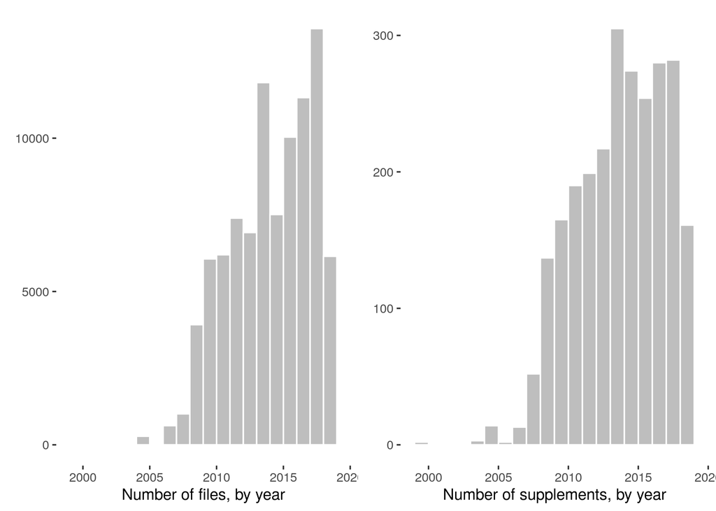

Distribution across years

### Number of files per supplement and size of supplement

|  | doi | size | count |
| --- | --- | --- | --- |
| 1 | 10.1257/pandp.20181045 | 32782817227 | 795 |
| 2 | 10.1257/pol.20150168 | 27251086584 | 691 |
| 3 | 10.1257/app.20170080 | 19924915397 | 236 |
| 4 | 10.1257/aer.20131496 | 15688843069 | 186 |
| 5 | 10.1257/app.20160510 | 14419727617 | 465 |
| 6 | 10.1257/app.6.3.206 | 12190878093 | 45 |
| 7 | 10.1257/aer.102.2.994 | 10789428265 | 36 |
| 8 | 10.1257/aer.20121662 | 10334181612 | 622 |
| 9 | 10.1257/mic.20130164 | 8042445763 | 20 |
| 10 | 10.1257/aer.20141374 | 6804364827 | 140 |

[output cut: 2550 more lines]

### Distribution overall

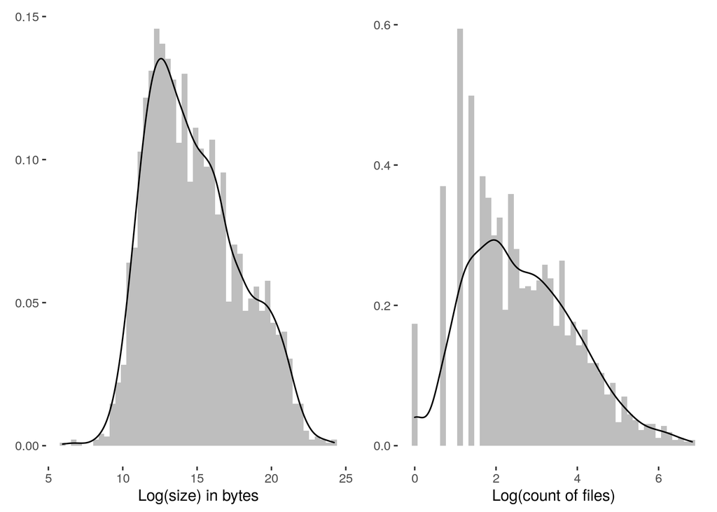

Distribution of filesizes and filecounts

### Stats by journal

Globally, the median supplement is 1.5 Mb and has 12. We can look at the size of the supplements by journal. The following table shows cumulative and median size and number of files.

| Journal | Articles | Median Size (Mb) | Cumulative Size (Mb) | Median no. of files | Total no. of files |
| --- | --- | --- | --- | --- | --- |
| American Economic Review | 1,238 | 1.4 | 165,552.8 | 13 | 50,310 |
| American Economic Journal: Applied Economics | 363 | 3.1 | 101,969.8 | 10 | 9,979 |
| American Economic Journal: Economic Policy | 351 | 4.2 | 98,574.0 | 12 | 12,585 |
| AEA Papers and Proceedings | 109 | 0.9 | 44,497.3 | 5 | 2,589 |
| American Economic Journal: Macroeconomics | 259 | 1.4 | 14,943.5 | 21 | 10,246 |
| American Economic Journal: Microeconomics | 115 | 1.1 | 12,899.3 | 10 | 5,448 |
| Journal of Economic Perspectives | 115 | 0.8 | 12,755.7 | 7 | 2,833 |
| Journal of Economic Literature | 7 | 17.8 | 432.1 | 67 | 623 |
| American Economic Review: Insights | 3 | 8.2 | 74.7 | 5 | 103 |

### Distribution across JEL codes

The top 10 JEL codes associated with supplements are:

|  | Number of packages | Pct | JEL | Description |
| --- | --- | --- | --- | --- |
| 1 | 263 | 10.31 | E32 | Business Fluctuations; Cycles |
| 2 | 245 | 9.6 | J24 | Human Capital; Skills; Occupational Choice; Labor Productivity |
| 3 | 217 | 8.5 | O15 | Economic Development: Human Resources; Human Development; Income Distribution; Migration |
| 4 | 214 | 8.39 | D12 | Consumer Economics: Empirical Analysis |
| 5 | 207 | 8.11 | J31 | Wage Level and Structure; Wage Differentials |
| 6 | 191 | 7.48 | J16 | Economics of Gender; Non-labor Discrimination |
| 7 | 183 | 7.17 | J13 | Fertility; Family Planning; Child Care; Children; Youth |
| 8 | 176 | 6.9 | I21 | Analysis of Education |
| 9 | 162 | 6.35 | D72 | Political Processes: Rent-seeking, Lobbying, Elections, Legislatures, and Voting Behavior |
| 10 | 157 | 6.15 | D83 | Search; Learning; Information and Knowledge; Communication; Belief |

[output cut: 554 more lines]

*A supplement can be associated with multiple JEL codes.*

### Software used

To identify software usage and data formats, we (manually) mapped file extensions into known software packages, and classified the file type into a set of categories:

| File type | Number of extensions |
| --- | --- |
| Program | 66 |
| Document | 36 |
| Data | 26 |
| Junk | 14 |
| Archive | 7 |
| Unknown | 3 |
| Logfile | 2 |

The table below shows the top ten software, by frequency of program files:

| Number of files | Pct | Software |
| --- | --- | --- |
| 19676 | 48.37 | Stata |
| 15244 | 37.47 | Matlab |
| 1750 | 4.30 | Fortran |
| 1084 | 2.66 | SAS |
| 659 | 1.62 | R |
| 454 | 1.12 | General |
| 416 | 1.02 | C |
| 291 | 0.72 | Unknown |
| 258 | 0.63 | None |
| 207 | 0.51 | Python |

The top software with respect to number of files is **Stata**. Note that there are 258 supplements that do not contain files that we have identified as program files (“None”).

More interesting is how many supplements use one or more software:

| Number of Software | N | Percent |
| --- | --- | --- |
| 1 | 2058 | 80.64 |
| 2 | 397 | 15.56 |
| 3+ | 105 | 4.11 |

with a maximum of 7 different software packages used in any one of the supplements. In turn, the number of supplements in which software is used at least once is reflected in the next table (restricted to at least 10 mentions):

| Name of Software | Usages | Percent |
| --- | --- | --- |
| Stata | 1862 | 72.96 |
| Matlab | 573 | 22.45 |
| None | 258 | 10.11 |
| SAS | 111 | 4.35 |
| R | 97 | 3.80 |
| Fortran | 64 | 2.51 |
| Python | 54 | 2.12 |
| Unknown | 37 | 1.45 |
| C | 34 | 1.33 |
| General | 29 | 1.14 |
| Shell | 29 | 1.14 |
| Windows | 24 | 0.94 |

Note:  
*Percentage sum to more than 100 percent, since a supplement can use multiple software packages.*

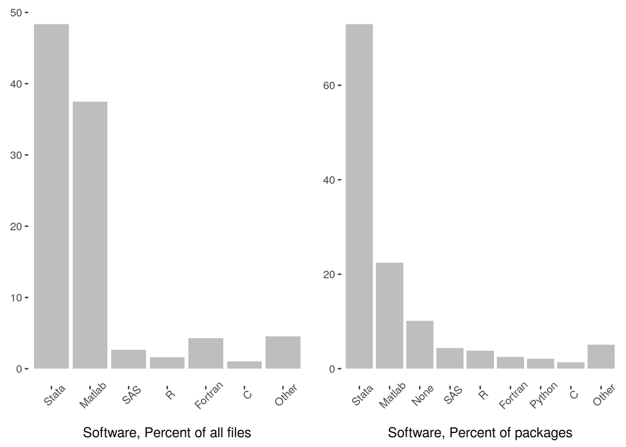

Software usage

Clearly, **Stata** is the most popular statistical software in the journals of the AEA (72.96 percent of all supplements use it), followed by **Matlab** (22.45 percent). Note again the 258 supplements that do not contain files that we have identified as program files (“None”).

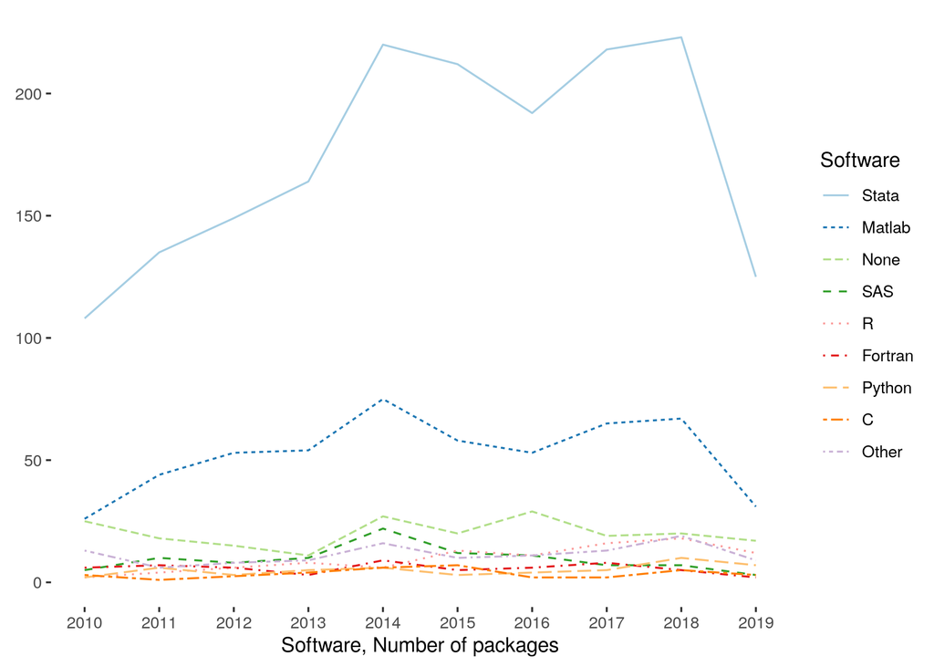

Software usage over time, number of supplements

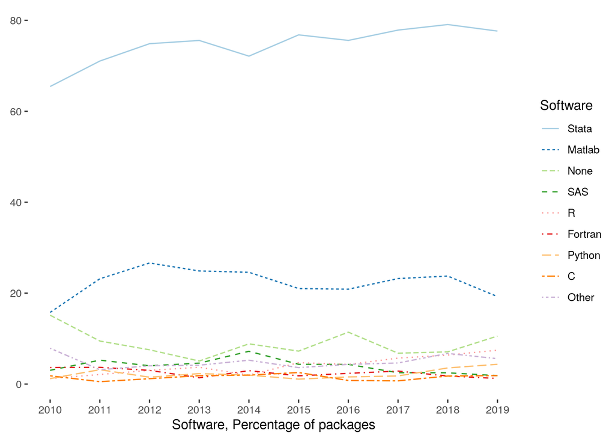

|  | Software_collapsed | year | n_doi | n_doi_year | Percent |
| --- | --- | --- | --- | --- | --- |
| 1 | Stata | 2004 | 2 | 3 | 66.67 |
| 2 | Stata | 2005 | 7 | 14 | 50 |
| 3 | Stata | 2007 | 8 | 13 | 61.54 |
| 4 | Stata | 2008 | 25 | 52 | 48.08 |
| 5 | Stata | 2009 | 74 | 137 | 54.01 |
| 6 | Stata | 2010 | 108 | 165 | 65.45 |
| 7 | Stata | 2011 | 135 | 190 | 71.05 |
| 8 | Stata | 2012 | 149 | 199 | 74.87 |
| 9 | Stata | 2013 | 164 | 217 | 75.58 |
| 10 | Stata | 2014 | 220 | 305 | 72.13 |

[output cut: 110 more lines]

### Data formats

It is somewhat more ambiguous identifying data files, as they come in a large variety of formats. Furthermore, data might be compressed. In the following table, we tabulate data files and archives, by the software package associated with their extension. The data type “General” encompasses formats like “tsv” or “csv” that are not associated with any particular software, but are nevertheless clearly identifiable as data files (full list available). We restrict ourselves to the number of supplements which contain files with such extensions.

| Name of Software | Usages | Percent |
| --- | --- | --- |
| Stata | 1392 | 44.90 |
| Excel | 682 | 22.00 |
| General | 547 | 17.65 |
| Matlab | 242 | 7.81 |
| Archive | 179 | 5.77 |
| SAS | 38 | 1.23 |
| R | 9 | 0.29 |
| OpenOffice | 5 | 0.16 |
| Unknown | 3 | 0.10 |
| SPSS | 2 | 0.06 |
| Julia | 1 | 0.03 |

## Metadata

When planning the migration, the preservation of existing metadata - the information about the data and code - was important. The AEA Data Editor worked with the openICPSR staff to enhance the data infrastructure, adding the capability to store and display JEL codes in addition to subject terms. Going forward, in addition to adding the JEL codes that also describe the linked article, authors can add metadata such as *geographic coverage*, *funding sources*, *time periods*, *geographic units* as well as *units of observation*, greatly enhancing the ability of researchers to find data through the openICPSR search interface.

Two important caveats apply, however. First, none of the additional metadata exists for the historical archives. Second, the openICPSR search interface only allows to search for these in an implicit way, i.e., one can search for “J31” because it is unlikely to appear as anything else, but there is no selection by specific JEL codes currently possible. The ability to do so is planned for a later implementation.

Metadata on which supplement at openICPSR relates to which article can be found in a few ways. First, in registering the new supplement DOI at openICPSR, a relationship link pointing to the article was created. A query to the [Datacite API](https://api.datacite.org/). For instance, the article with the largest supplement had article DOI 10.1257/pandp.20181045. The associated supplement now has DOI 10.3886/E114448V1. The Datacite API query for the supplement would be https://api.datacite.org/dois/10.3886/E114448V1, and querying this URL would yield a [JSON](https://www.json.org/) object, identifying the link:

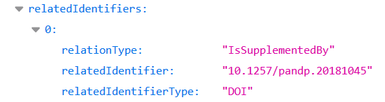

Partial JSON from query

Alternatively, we have created a linkage file, available at https://github.com/AEADataEditor/aea-supplement-migration/blob/master/data/generated/table.aea.icpsr.mapping.csv, containing the article DOI, the title of the paper, and the supplement DOI at openICPSR:

| doi | icpsr_doi | title |
| --- | --- | --- |
| 10.1257/0002828043052196 | 10.3886/E112306V1 | Progressive Taxation and Long-Run Growth |
| 10.1257/0002828043052358 | 10.3886/E112307V1 | The Effect of Health Risk on Housing Values: Evidence from a Cancer Cluster |
| 10.1257/0002828053828446 | 10.3886/E112308V1 | The Sensitivity of Long-Term Interest Rates to Economic News: Evidence and Implications for Macroeconomic Models |
| 10.1257/0002828053828455 | 10.3886/E112309V1 | Will U.S. Agriculture Really Benefit from Global Warming? Accounting for Irrigation in the Hedonic Approach |
| 10.1257/0002828053828509 | 10.3886/E112310V1 | Patent Citations and the Geography of Knowledge Spillovers: A Reassessment |
| 10.1257/0002828053828635 | 10.3886/E112311V1 | Why the Apple Doesn’t Fall Far: Understanding Intergenerational Transmission of Human Capital |

## Code Availability

The code underlying this analysis can be downloaded at https://github.com/AEADataEditor/aea-supplement-migration.

## References

Armour, Phillip, Patrick Button, and Simon Hollands. 2018. “Disability Saliency and Discrimination in Hiring.” *AEA Papers and Proceedings* 108: 262–66. https://doi.org/10.1257/pandp.20181045.